# A3: SPL Library Checkouts

### Introduction

The assignment centers around a dataset about the recording of items checked out at least 10 times a month issued by the Seattle Public Library from 2017 to 2023.

I would like to see how the digitization and pandemic shape the relationship between people and all kinds of media, and compare the trend of old, physical media and new, digital media. Another question would be to check how the trend of the types of the book (E-book or traditional book) people read has changed, and see how much of those types changed. Media is a important part in people’s everyday life. It would be interesting to see if digitization affects people’s ways of accepting information, or if people simply follows their old habits and not affected by the pandemic and developing technology. Also, quarantine affected the available types of the media people can borrow, so that can affect maybe the habits that they kept for years. So I also want to know if pandemic force people to find new sources of media to replace the library.

### Summary Information

The following is a summary for both the SPL data frames:

Spl Summary:

nrow : 816354,

n_distinct_UsageClass : 2,

n_distinct_CheckoutType : 5,

n_distinct_MaterialType : 32,

max_CheckoutYear : 2023,

min_CheckoutYear : 2017,

max_CheckoutMonth : 12,

min_CheckoutMonth : 1,

max_Checkouts : 4903,

min_Checkouts : 10,

mean_Checkouts : 23.4773995105065,

median_Checkouts : 15

### The Dataset

The data was found on Seattle Public Library: https://data.seattle.gov/Community/Checkouts-by-Title/tmmm-ytt6

Dataset Owner - SPL, Provided by: The Seattle Public Library.

This data is documented by Seattle Public Library to track on all of the medias borrowed from the library. All book must be recorded when borrowed from the library, and therefore those records are traced to provide the data of the media in the library.

Collection of this data began due to the rules and requirement of The Seattle Public Library.  
12 Columns: UsageClass, CheckoutType, MaterialType, CheckoutYear, CheckoutMonth, Checkouts, Title, ISBN, Creator, Subjects, Publisher, PublicationYear.

I find some limitations when I writing the explanation. First, I mentioned that library also become digital, then I wonder if the library also records the check out for a E-book online? I do not find the data set explaining this point. Also, like the FAQ said, some of the subject headings blank which is a problem for this data and this problem is very common in ISBN column. Having blank headings for a subject will make the trend that chart created based on the data lose precise. This becomes especially worse if someone pick one or two author or genre to analyze, so I avoid to pick any of those two variables. For ISBN, ignoring the blank, I see many items hacing multiple ISBN, FAQs does not have the answer so I searched on Google for reason, I assume it is because there exist multiple versions like electronic version, audio version, and paper version, etc. But the data does not tell user which ISBN is assigned to which version, and this may cause confusion for people who want to use ISBN as an index to search for a special version of a book. I think this is another defect for this data set.

### First Trends Over Time Chart

I choose this chart to compare the relationship between the time and the type of media people borrowed from the library. I thought maybe this chart would show the trend of people accepting information through media under both the effect of technology and the pandemic. In fact, I think the chart not only shows the trend of media and the result of the pandemic but also combines those two factors perfectly.

First, from the graph, I can see there is a mild decrease per year for physical type media and a huge increase in the digital type of borrowed media before 2020. I have the same feeling that media is becoming more common in digital form on the Internet instead of using physical form. For example, people nowadays tend to listen to music or watch movies on apps like Spotify or Netflix instead of buying CDs, when you want to see news, your first action is to open your phone but not find today’s newspaper. This shows the trend of digitizing media.

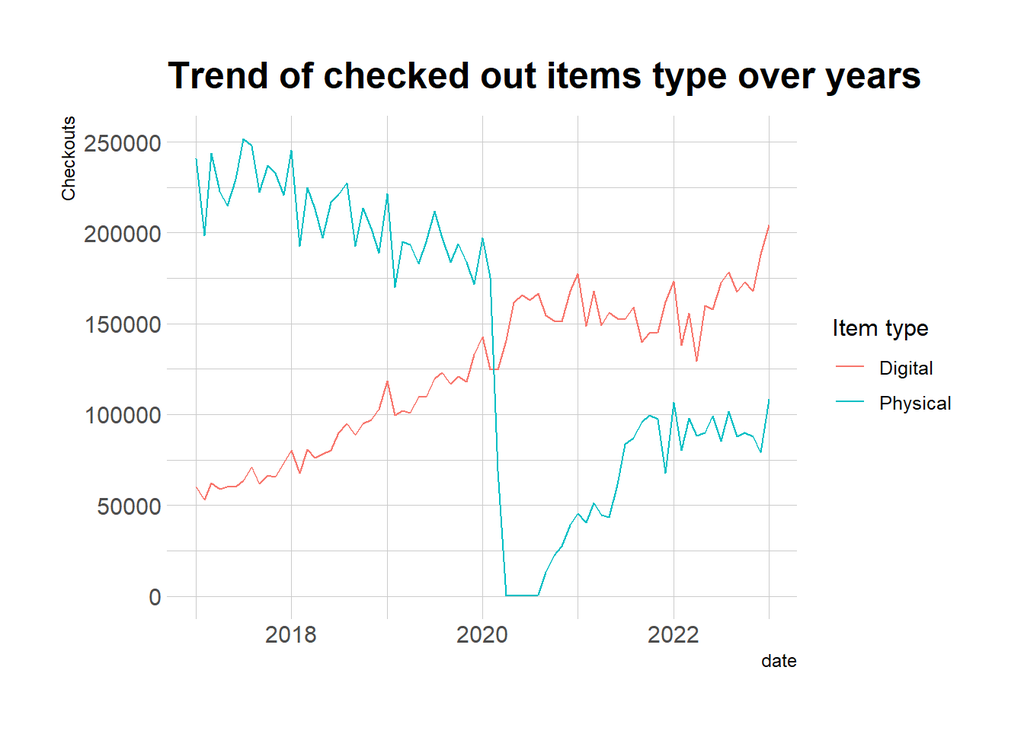

### Second Trends Over Time Chart

I choose to include the second chart to compare the relation between time and Audio book and E-book. I want to see under the digitizing media, how is the trend of book, as a type and probably the most important type of media, changed over the time.

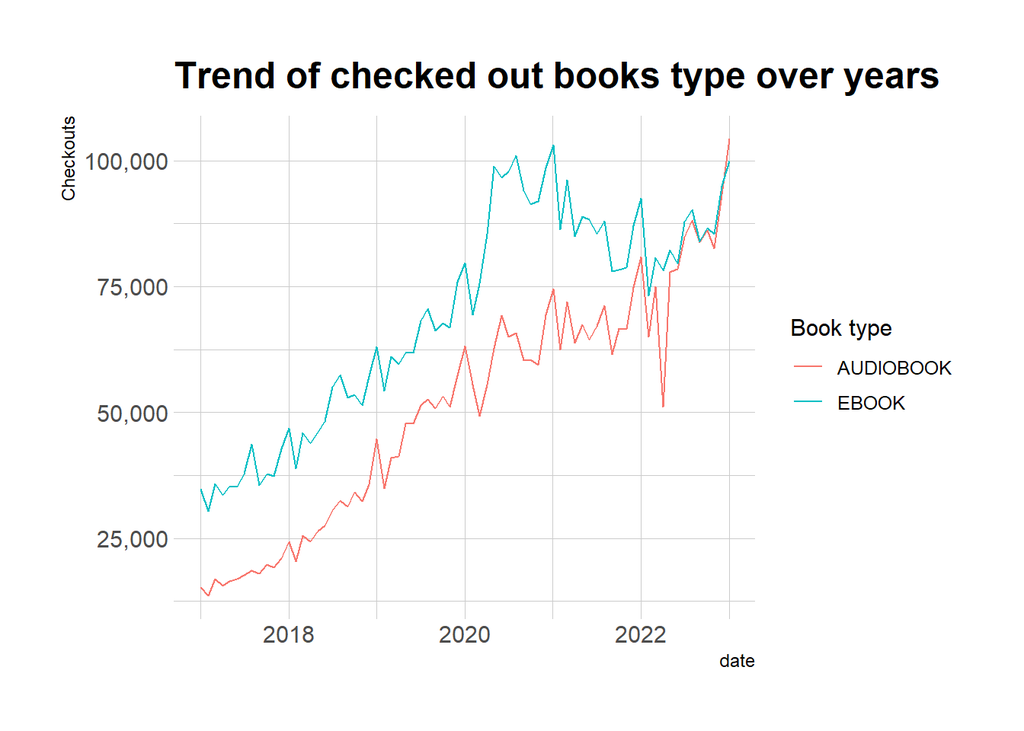

### Your Choice

So I choose the third one as a pie chart to reveal the relation of total check outs and the time.

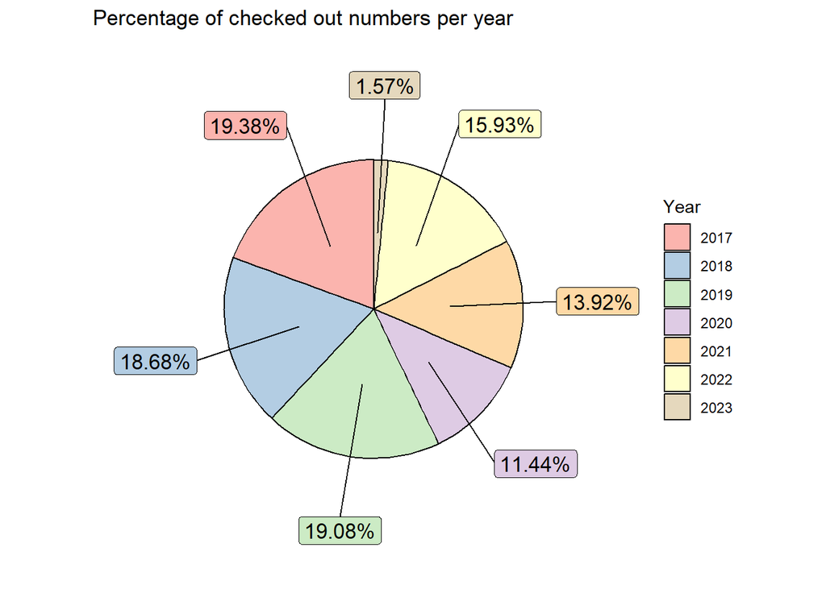